# Time Series AF Shifts

# Genome-wide allele frequency shifts

## Within population all chromosomes

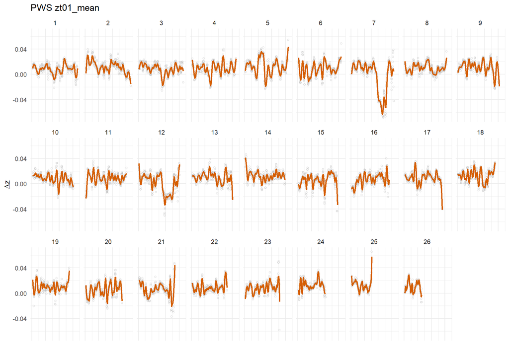

```r
plot_af_chromosomes <- function(pop,years,win,step){

freqs_win <- read.table(paste("C:/Users/jmcgirr/Documents/Whitehead_Lab/ph/freqs/window/",pop,"_shifts_",win,"_win_",step,"_step.txt", sep = ""))
freqs_win$chr_num <- factor(freqs_win$chr, levels = c(1:26))

p <- ggplot(freqs_win, aes_string(x = "win_mid", y = years)) +
     geom_point(size = 1, color = gry,alpha = 0.7, shape = 1)+
     theme_minimal()+
     theme(axis.text.x=element_blank())+
     ylab(expression(paste(Delta, "z")))+ xlab("")+
     geom_smooth(method = "loess", se = FALSE, span = 1/10, color = red)+
     facet_wrap(~chr_num, ncol = 9)+
     ggtitle(paste(pop,years, sep = " "))
print(p)
}


plot_af_chromosomes_within <- function(pop,win,step){

freqs_win <- read.table(paste("C:/Users/jmcgirr/Documents/Whitehead_Lab/ph/freqs/window/",pop,"_shifts_",win,"_win_",step,"_step.txt", sep = ""))
freqs_win$chr_num <- factor(freqs_win$chr, levels = c(1:26))
p <- ggplot(freqs_win, aes_string(x = "win_mid", y = "zt01_mean")) +
  theme_minimal()+
  theme(axis.text.x=element_blank())+
  ylab(expression(paste(Delta, "z")))+ xlab("")+
  geom_smooth(aes_string(x = "win_mid", y = "zt01_mean", color = "grb"),method = "loess", se = FALSE, span = 1/10)+
  geom_smooth(aes_string(x = "win_mid", y = "zt12_mean", color = "lir"),method = "loess", se = FALSE, span = 1/10)+
  geom_smooth(aes_string(x = "win_mid", y = "zt23_mean", color = "org"),method = "loess", se = FALSE, span = 1/10)+
  facet_wrap(~chr_num, ncol = 9)+
  scale_color_manual(values=c(lir,grb,org),name = "contrast",
                     labels = c("1991-1996", "1996-2007", "2007-2017"))+
  ylim(-0.05, 0.05)+theme(legend.position = c(0.95, 0.2))+
  ggtitle(pop)
print(p)

}


# Within Population

pop <- "PWS"
plot_af_chromosomes(pop,"zt01_mean",win,step)
```

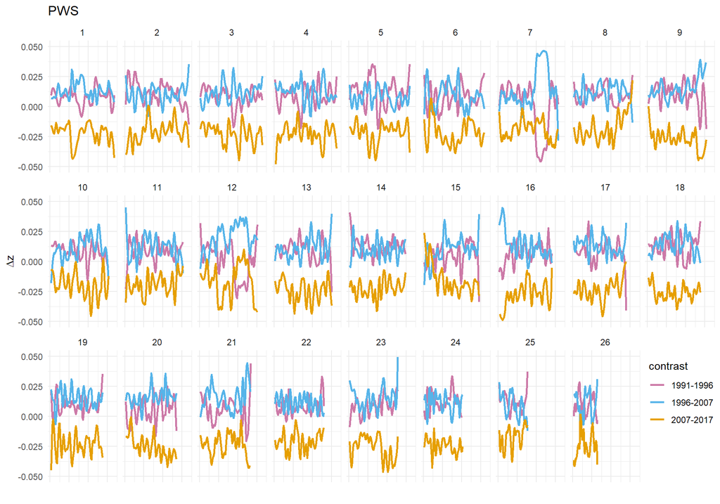

```r
#plot_af_chromosomes(pop,"zt12_mean",win,step)
#plot_af_chromosomes(pop,"zt23_mean",win,step)
plot_af_chromosomes_within(pop,win,step)
```

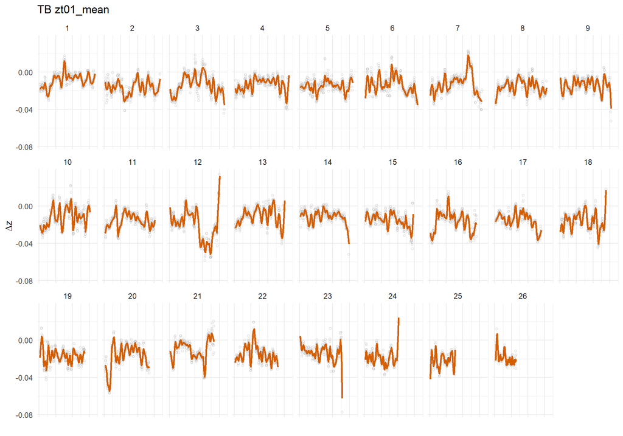

```r
pop <- "TB"
plot_af_chromosomes(pop,"zt01_mean",win,step)
```

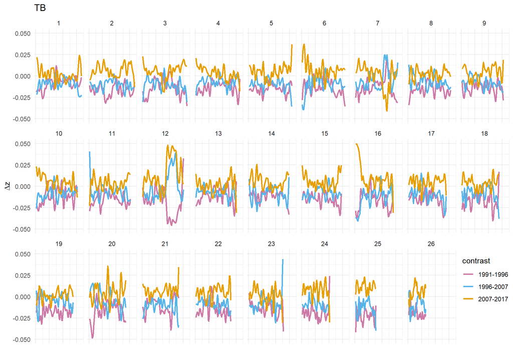

```r
#plot_af_chromosomes(pop,"zt12_mean",win,step)
#plot_af_chromosomes(pop,"zt23_mean",win,step)
plot_af_chromosomes_within(pop,win,step)
```

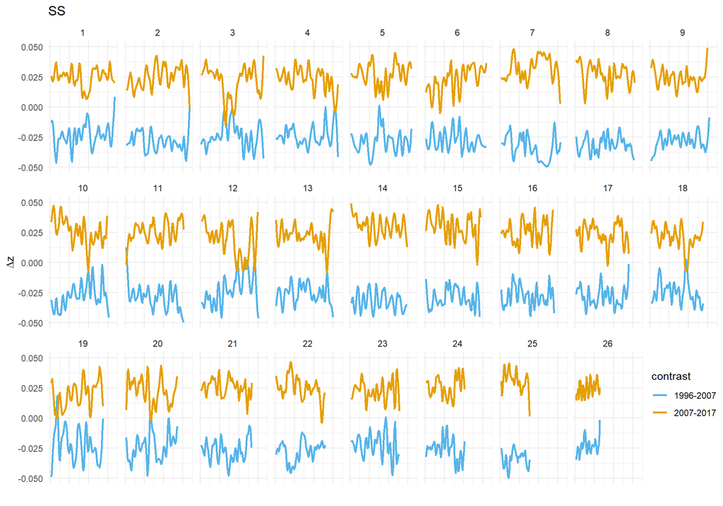

```r
pop <- "SS"
#plot_af_chromosomes(pop,"zt12_mean",win,step)
#plot_af_chromosomes(pop,"zt23_mean",win,step)

freqs_win <- read.table(paste("C:/Users/jmcgirr/Documents/Whitehead_Lab/ph/freqs/window/",pop,"_shifts_",win,"_win_",step,"_step.txt", sep = ""))
freqs_win$chr_num <- factor(freqs_win$chr, levels = c(1:26))

p <- ggplot(freqs_win, aes_string(x = "win_mid", y = "zt12_mean")) +
  theme_minimal()+
  theme(axis.text.x=element_blank())+
  ylab(expression(paste(Delta, "z")))+ xlab("")+
  geom_smooth(aes_string(x = "win_mid", y = "zt12_mean", color = "grb"),method = "loess", se = FALSE, span = 1/10)+
  geom_smooth(aes_string(x = "win_mid", y = "zt23_mean", color = "org"),method = "loess", se = FALSE, span = 1/10)+
  facet_wrap(~chr_num, ncol = 9)+
  scale_color_manual(values=c(grb,org),name = "contrast",
                     labels = c("1996-2007", "2007-2017"))+
  ylim(-0.05, 0.05)+theme(legend.position = c(0.95, 0.2))+
  ggtitle(pop)
print(p)
```

## Within population chromosomes with putative inversions (7,12,15,16,20)

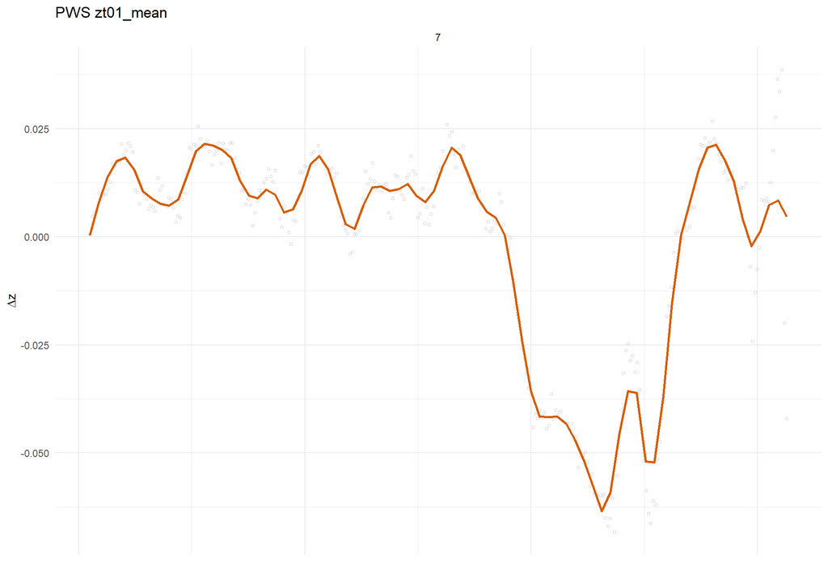

```r
plot_af_chromosome <- function(pop,years,win,step,chrs){

freqs_win <- read.table(paste("C:/Users/jmcgirr/Documents/Whitehead_Lab/ph/freqs/window/",pop,"_shifts_",win,"_win_",step,"_step.txt", sep = ""))
freqs_win$chr_num <- factor(freqs_win$chr, levels = c(1:26))
freqs_win <- freqs_win[freqs_win$chr_num %in% chrs,]

p <- ggplot(freqs_win, aes_string(x = "win_mid", y = "zt01_mean")) +
     geom_point(size = 1, color = gry,alpha = 0.7, shape = 1)+
     theme_minimal()+
     theme(axis.text.x=element_blank())+
     ylab(expression(paste(Delta, "z")))+ xlab("")+
     geom_smooth(method = "loess", se = FALSE, span = 1/10, color = red)+
     facet_wrap(~chr_num, ncol = 1)+
     ggtitle(paste(pop,years, sep = " "))
print(p)
}


plot_af_chromosome_within <- function(pop,win,step,chrs){

freqs_win <- read.table(paste("C:/Users/jmcgirr/Documents/Whitehead_Lab/ph/freqs/window/",pop,"_shifts_",win,"_win_",step,"_step.txt", sep = ""))
freqs_win$chr_num <- factor(freqs_win$chr, levels = c(1:26))
freqs_win <- freqs_win[freqs_win$chr_num %in% chrs,]

p <- ggplot(freqs_win, aes_string(x = "win_mid", y = "zt01_mean")) +
  theme_minimal()+
  theme(axis.text.x=element_blank())+
  ylab(expression(paste(Delta, "z")))+ xlab("")+
  geom_smooth(aes_string(x = "win_mid", y = "zt01_mean", color = "grb"),method = "loess", se = FALSE, span = 1/10)+
  geom_smooth(aes_string(x = "win_mid", y = "zt12_mean", color = "lir"),method = "loess", se = FALSE, span = 1/10)+
  geom_smooth(aes_string(x = "win_mid", y = "zt23_mean", color = "org"),method = "loess", se = FALSE, span = 1/10)+
  facet_wrap(~chr_num, ncol = 3)+
  scale_color_manual(values=c(lir,grb,org),name = "contrast",
                     labels = c("1991-1996", "1996-2007", "2007-2017"))+
  ylim(-0.05, 0.05)+
  ggtitle(pop)
print(p)

}

# chr 7
pop <- "PWS"
chrs <- c(7)

plot_af_chromosome(pop,"zt01_mean",win,step,chrs)
```

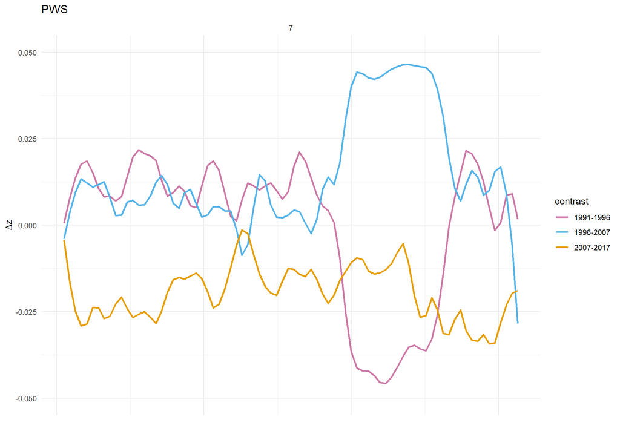

```r
#plot_af_chromosome(pop,"zt12_mean",win,step,chrs)
#plot_af_chromosome(pop,"zt23_mean",win,step,chrs)
plot_af_chromosome_within(pop,win,step,chrs)
```

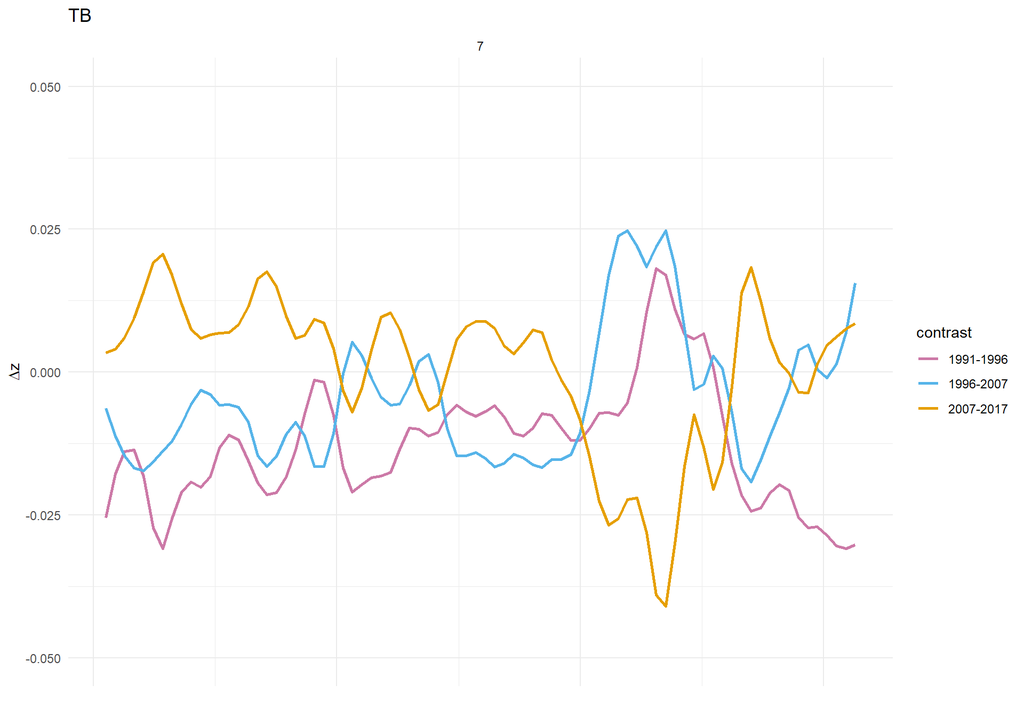

```r
pop <- "TB"
plot_af_chromosome_within(pop,win,step,chrs)
```

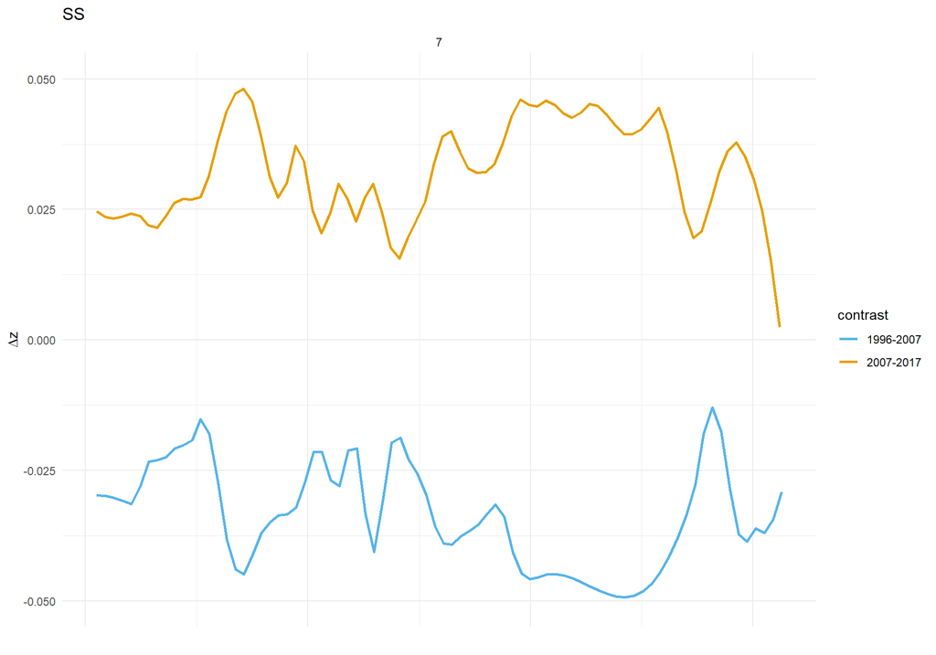

```r
pop <- "SS"
freqs_win <- read.table(paste("C:/Users/jmcgirr/Documents/Whitehead_Lab/ph/freqs/window/",pop,"_shifts_",win,"_win_",step,"_step.txt", sep = ""))
freqs_win$chr_num <- factor(freqs_win$chr, levels = c(1:26))
freqs_win <- freqs_win[freqs_win$chr_num %in% chrs,]

p <- ggplot(freqs_win, aes_string(x = "win_mid", y = "zt12_mean")) +
  theme_minimal()+
  theme(axis.text.x=element_blank())+
  ylab(expression(paste(Delta, "z")))+ xlab("")+
  geom_smooth(aes_string(x = "win_mid", y = "zt12_mean", color = "lir"),method = "loess", se = FALSE, span = 1/10)+
  geom_smooth(aes_string(x = "win_mid", y = "zt23_mean", color = "org"),method = "loess", se = FALSE, span = 1/10)+
  facet_wrap(~chr_num, ncol = 3)+
  scale_color_manual(values=c(grb,org),name = "contrast",
                     labels = c("1996-2007", "2007-2017"))+
  ylim(-0.05, 0.05)+
  ggtitle(pop)
print(p)
```

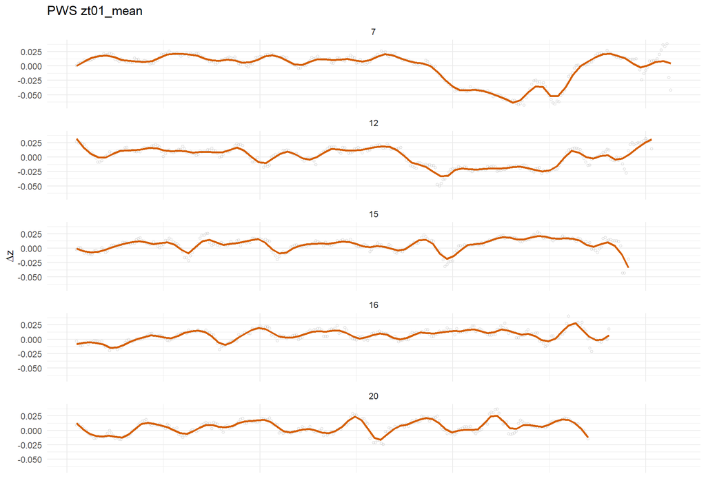

```r
# all inversions
pop <- "PWS"
years <- "zt01_mean"
win <- "1mb"
step <- "100kb"
chrs <- c(7,12,15,16,20)

plot_af_chromosome(pop,"zt01_mean",win,step,chrs)
```

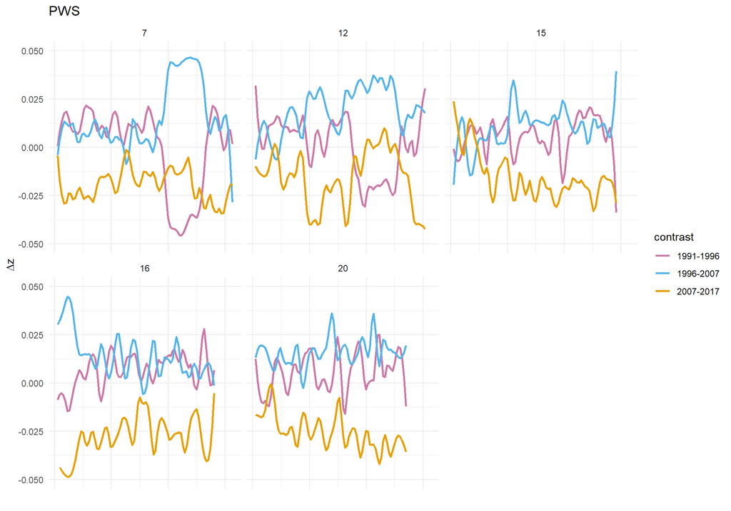

```r
plot_af_chromosome_within(pop,win,step,chrs)
```

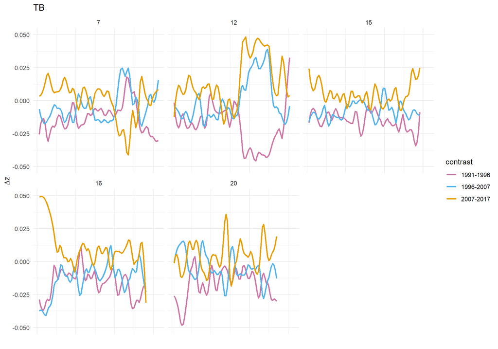

```r
pop <- "TB"
plot_af_chromosome_within(pop,win,step,chrs)
```

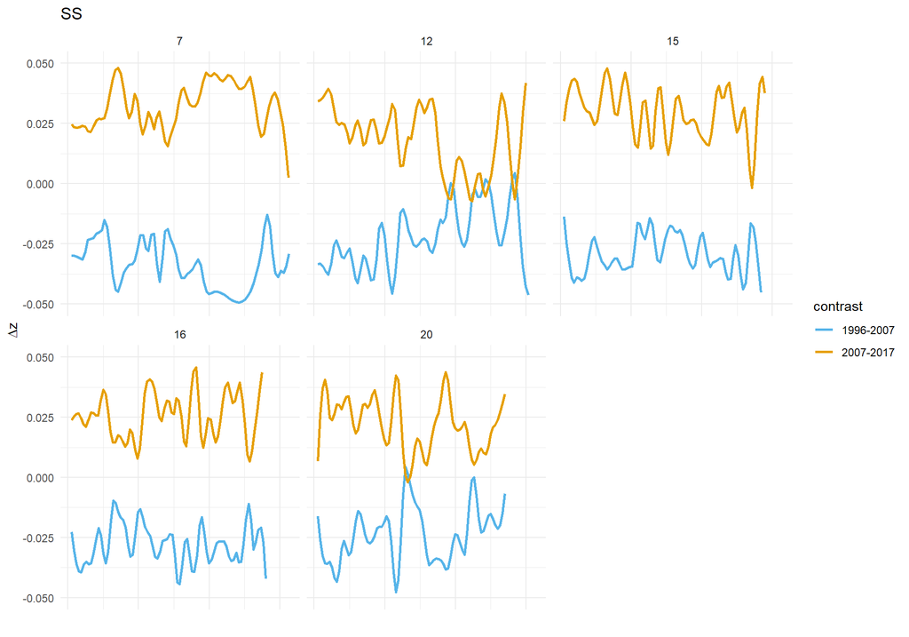

```r
pop <- "SS"
freqs_win <- read.table(paste("C:/Users/jmcgirr/Documents/Whitehead_Lab/ph/freqs/window/",pop,"_shifts_",win,"_win_",step,"_step.txt", sep = ""))
freqs_win$chr_num <- factor(freqs_win$chr, levels = c(1:26))
freqs_win <- freqs_win[freqs_win$chr_num %in% chrs,]

p <- ggplot(freqs_win, aes_string(x = "win_mid", y = "zt12_mean")) +
  theme_minimal()+
  theme(axis.text.x=element_blank())+
  ylab(expression(paste(Delta, "z")))+ xlab("")+
  geom_smooth(aes_string(x = "win_mid", y = "zt12_mean", color = "lir"),method = "loess", se = FALSE, span = 1/10)+
  geom_smooth(aes_string(x = "win_mid", y = "zt23_mean", color = "org"),method = "loess", se = FALSE, span = 1/10)+
  facet_wrap(~chr_num, ncol = 3)+
  scale_color_manual(values=c(grb,org),name = "contrast",
                     labels = c("1996-2007", "2007-2017"))+
  ylim(-0.05, 0.05)+
  ggtitle(pop)
print(p)
```

## Between Populations

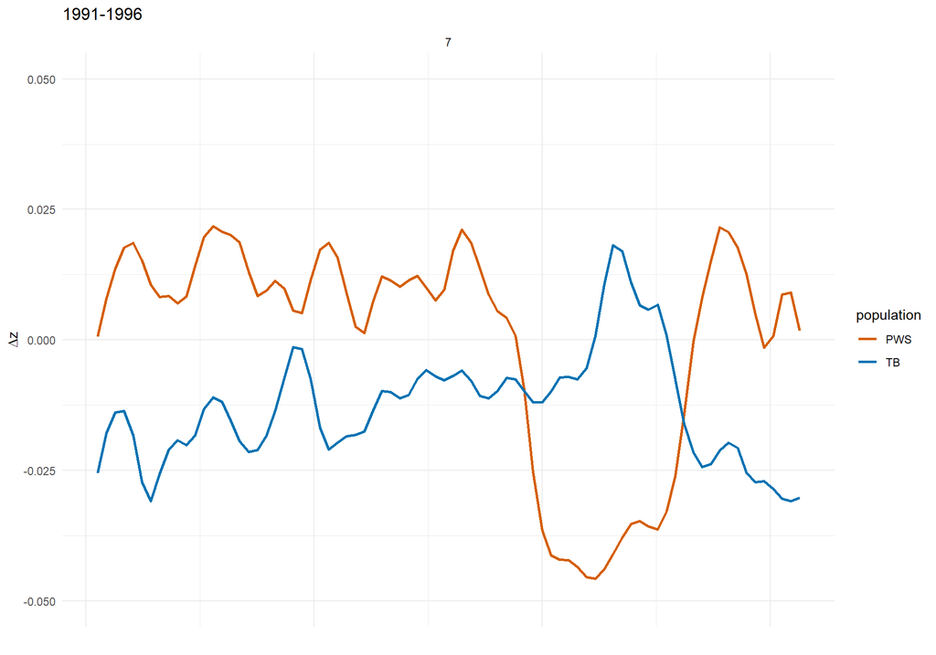

```r
# chr 7
chrs <- c(7)

all_pops1 <- all_pops[all_pops$chr_num %in% chrs,]
p <- ggplot(all_pops1, aes_string(x = "win_mid", y = "zt01_p")) +
     theme_minimal()+
     theme(axis.text.x=element_blank())+
     facet_wrap(~chr_num, ncol = 9)+
     ylab(expression(paste(Delta, "z")))+ xlab("")+
     geom_smooth(aes_string(x = "win_mid", y = "zt01_p", color = "blu"),
                 method = "loess", se = FALSE, span = 1/10)+
     geom_smooth(aes_string(x = "win_mid", y = "zt01_t", color = "red"),
                 method = "loess", se = FALSE, span = 1/10)+
  scale_color_manual(values=c(red,blu),name = "population",
                     labels = c("PWS","TB"))+
  ylim(-0.05, 0.05)+
  ggtitle("1991-1996")

print(p)
```

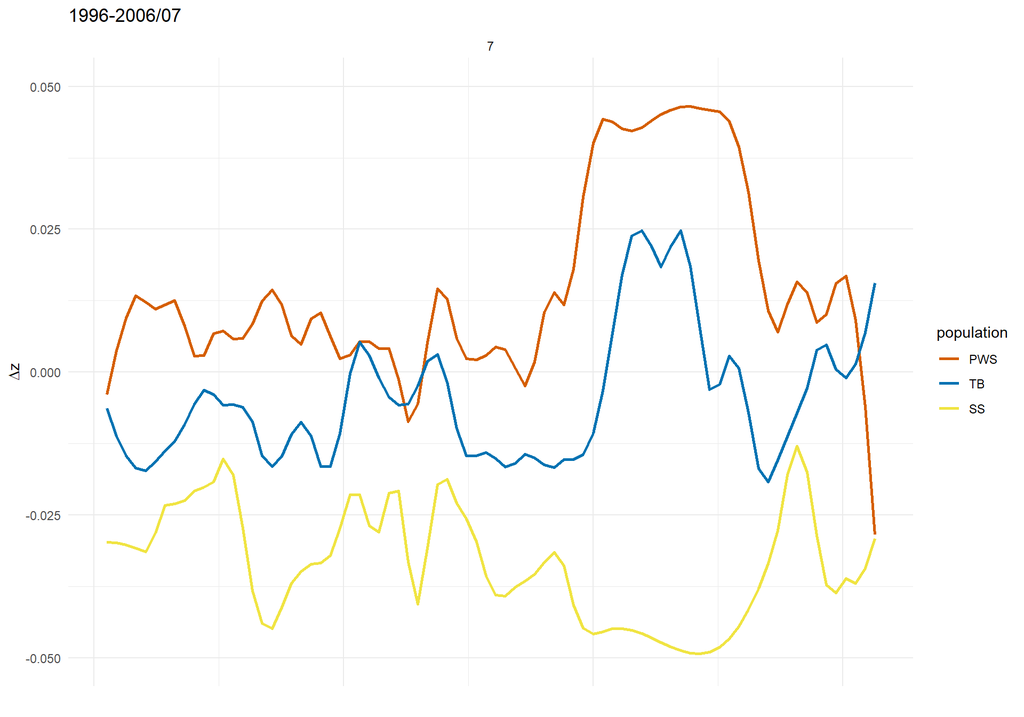

```r
p <- ggplot(all_pops1, aes_string(x = "win_mid", y = "zt01_p")) +
     theme_minimal()+
     theme(axis.text.x=element_blank())+
     facet_wrap(~chr_num, ncol = 9)+
     ylab(expression(paste(Delta, "z")))+ xlab("")+
     geom_smooth(aes_string(x = "win_mid", y = "zt12_p", color = "blu"),
                 method = "loess", se = FALSE, span = 1/10)+
     geom_smooth(aes_string(x = "win_mid", y = "zt12_t", color = "red"),
                 method = "loess", se = FALSE, span = 1/10)+
       geom_smooth(aes_string(x = "win_mid", y = "zt12_s", color = "yel"),
                 method = "loess", se = FALSE, span = 1/10)+
  scale_color_manual(values=c(red,blu,yel),name = "population",
                     labels = c("PWS","TB","SS"))+
  ylim(-0.05, 0.05)+
  ggtitle("1996-2006/07")

print(p)
```

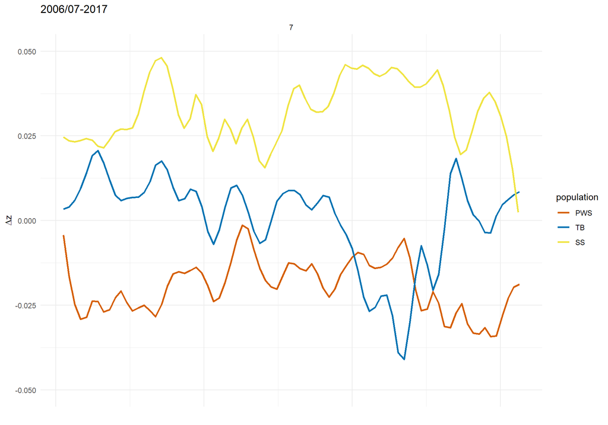

```r
p <- ggplot(all_pops1, aes_string(x = "win_mid", y = "zt01_p")) +
     theme_minimal()+
     theme(axis.text.x=element_blank())+
     facet_wrap(~chr_num, ncol = 9)+
     ylab(expression(paste(Delta, "z")))+ xlab("")+
     geom_smooth(aes_string(x = "win_mid", y = "zt23_p", color = "blu"),
                 method = "loess", se = FALSE, span = 1/10)+
     geom_smooth(aes_string(x = "win_mid", y = "zt23_t", color = "red"),
                 method = "loess", se = FALSE, span = 1/10)+
     geom_smooth(aes_string(x = "win_mid", y = "zt23_s", color = "yel"),
                 method = "loess", se = FALSE, span = 1/10)+
     scale_color_manual(values=c(red,blu,yel),name = "population",
                        labels = c("PWS","TB","SS"))+
  ylim(-0.05, 0.05)+
  ggtitle("2006/07-2017")

print(p)
```

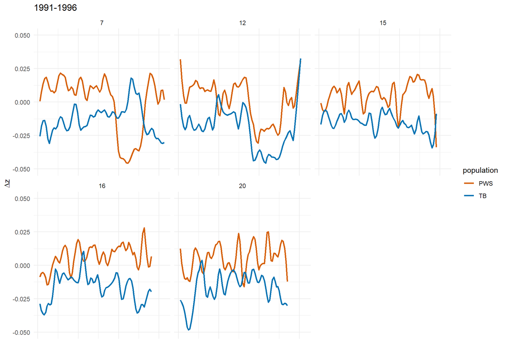

```r
# all inversions
chrs <- c(7,12,15,16,20)

all_pops1 <- all_pops[all_pops$chr_num %in% chrs,]
p <- ggplot(all_pops1, aes_string(x = "win_mid", y = "zt01_p")) +
     theme_minimal()+
     theme(axis.text.x=element_blank())+
     facet_wrap(~chr_num, ncol = 3)+
     ylab(expression(paste(Delta, "z")))+ xlab("")+
     geom_smooth(aes_string(x = "win_mid", y = "zt01_p", color = "blu"),
                 method = "loess", se = FALSE, span = 1/10)+
     geom_smooth(aes_string(x = "win_mid", y = "zt01_t", color = "red"),
                 method = "loess", se = FALSE, span = 1/10)+
  scale_color_manual(values=c(red,blu),name = "population",
                     labels = c("PWS","TB"))+
  ylim(-0.05, 0.05)+
  ggtitle("1991-1996")

print(p)
```

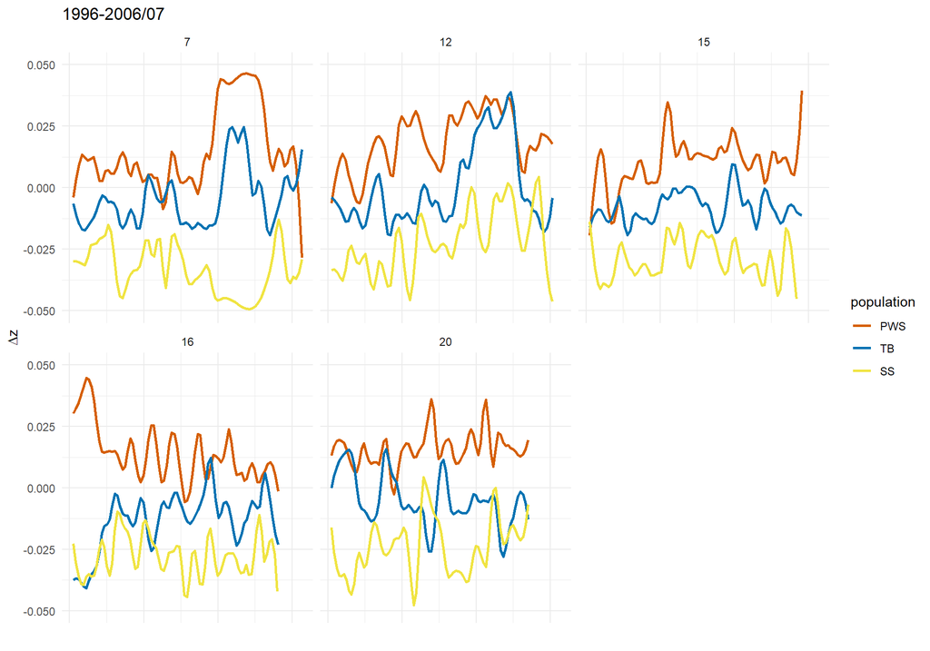

```r
p <- ggplot(all_pops1, aes_string(x = "win_mid", y = "zt01_p")) +
     theme_minimal()+
     theme(axis.text.x=element_blank())+
     facet_wrap(~chr_num, ncol = 3)+
     ylab(expression(paste(Delta, "z")))+ xlab("")+
     geom_smooth(aes_string(x = "win_mid", y = "zt12_p", color = "blu"),
                 method = "loess", se = FALSE, span = 1/10)+
     geom_smooth(aes_string(x = "win_mid", y = "zt12_t", color = "red"),
                 method = "loess", se = FALSE, span = 1/10)+
       geom_smooth(aes_string(x = "win_mid", y = "zt12_s", color = "yel"),
                 method = "loess", se = FALSE, span = 1/10)+
  scale_color_manual(values=c(red,blu,yel),name = "population",
                     labels = c("PWS","TB","SS"))+
  ylim(-0.05, 0.05)+
  ggtitle("1996-2006/07")

print(p)
```

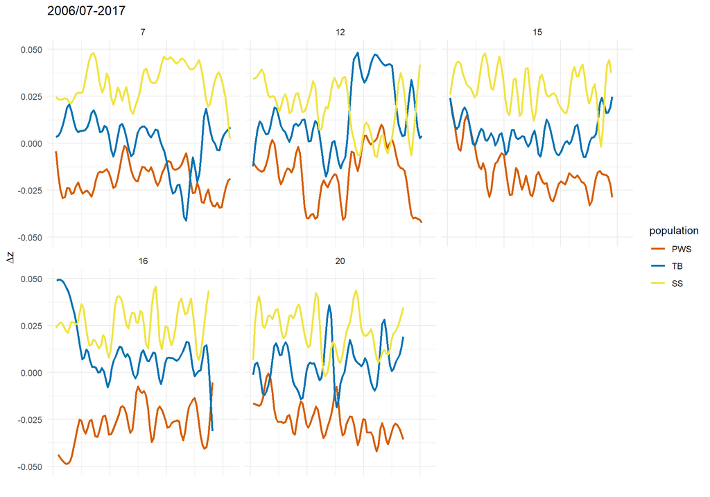

```r
p <- ggplot(all_pops1, aes_string(x = "win_mid", y = "zt01_p")) +
     theme_minimal()+
     theme(axis.text.x=element_blank())+
     facet_wrap(~chr_num, ncol = 3)+
     ylab(expression(paste(Delta, "z")))+ xlab("")+
     geom_smooth(aes_string(x = "win_mid", y = "zt23_p", color = "blu"),
                 method = "loess", se = FALSE, span = 1/10)+
     geom_smooth(aes_string(x = "win_mid", y = "zt23_t", color = "red"),
                 method = "loess", se = FALSE, span = 1/10)+
     geom_smooth(aes_string(x = "win_mid", y = "zt23_s", color = "yel"),
                 method = "loess", se = FALSE, span = 1/10)+
     scale_color_manual(values=c(red,blu,yel),name = "population",
                        labels = c("PWS","TB","SS"))+
  ylim(-0.05, 0.05)+
  ggtitle("2006/07-2017")

print(p)
```

# Identify windows where allele frequencies showed shifts in the same direction

Out of 70234 50kb windows, what percentage consistently:

- increased between each sampling period
- decreased between each sampling period

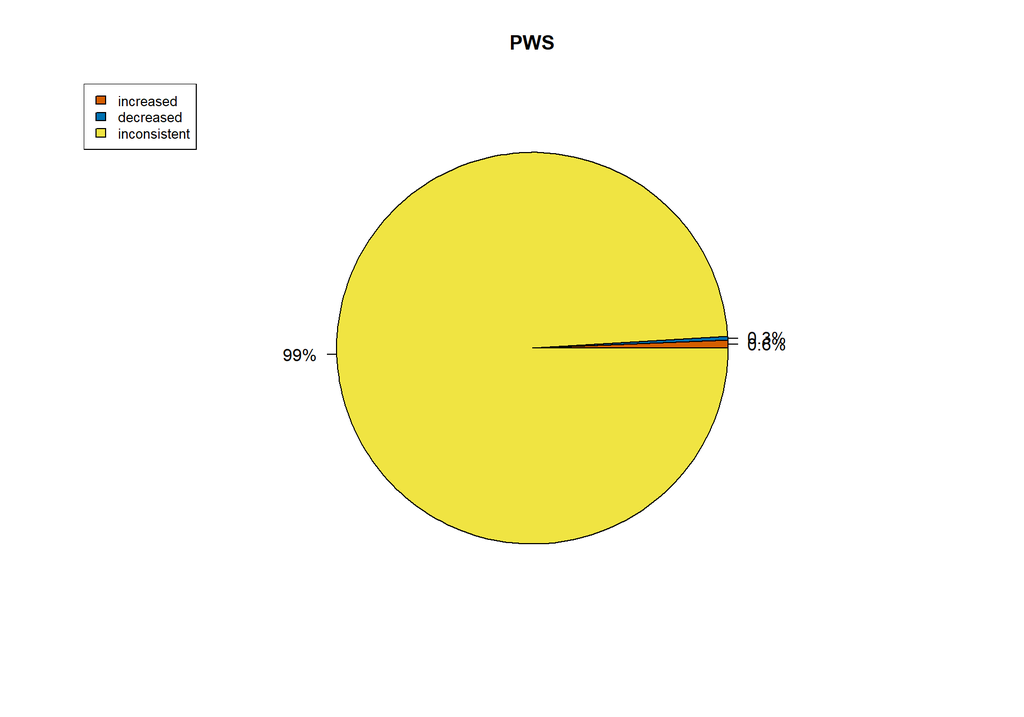

```r
pop <- "PWS"

freqs_win <- read.table(paste("C:/Users/jmcgirr/Documents/Whitehead_Lab/ph/freqs/window/",pop,"_shifts_",win,"_win_",step,"_step.txt", sep = ""))
freqs_win$chr_num <- factor(freqs_win$chr, levels = c(1:26))
colnames(freqs_win)[c(1:3)] <- c("seqnames","start","end")


# identify windows where allele frequencies increased between each sampling period
pws_increased_freq <- freqs_win[freqs_win$zt01_mean > 0 &
                            freqs_win$zt12_mean > 0 &
                            freqs_win$zt23_mean > 0,]
#nrow(increased_freq)
#nrow(increased_freq) / nrow(freqs_win)
# identify windows where allele frequencies increased between each sampling period
pws_decreased_freq <- freqs_win[freqs_win$zt01_mean < 0 &
                            freqs_win$zt12_mean < 0 &
                            freqs_win$zt23_mean < 0,]
#nrow(decreased_freq)
#nrow(decreased_freq) / nrow(freqs_win)

inc <- nrow(pws_increased_freq)
dec <- nrow(pws_decreased_freq)
remain <- nrow(freqs_win)-(inc+dec)

p <- pie(c(inc,dec,remain), col = c(red, blu, yel), main = pop,
      labels = c(paste(round(inc/nrow(freqs_win),3)*100, "%", sep = ""),
                 paste(round(dec/nrow(freqs_win),3)*100, "%", sep = ""),
                 paste(round(remain/nrow(freqs_win),3)*100, "%", sep = "")))

l <- legend("topleft", c("increased", "decreased", "inconsistent"), cex = 0.8,
   fill = c(red, blu, yel))
```

```r
print(p)
```

```r
print(l)
```

[output not shown]

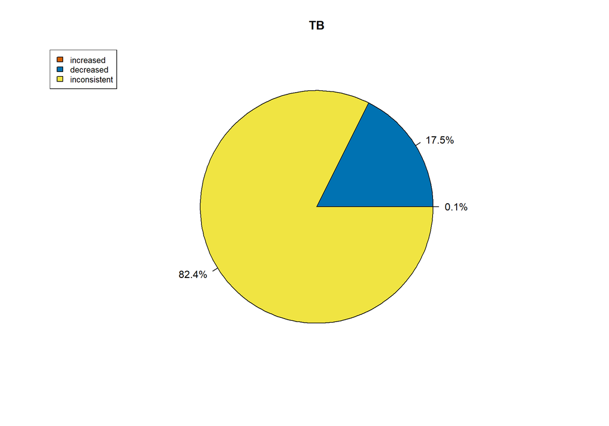

```r
pop <- "TB"

freqs_win <- read.table(paste("C:/Users/jmcgirr/Documents/Whitehead_Lab/ph/freqs/window/",pop,"_shifts_",win,"_win_",step,"_step.txt", sep = ""))
freqs_win$chr_num <- factor(freqs_win$chr, levels = c(1:26))
colnames(freqs_win)[c(1:3)] <- c("seqnames","start","end")


# identify windows where allele frequencies increased between each sampling period
tb_increased_freq <- freqs_win[freqs_win$zt01_mean > 0 &
                            freqs_win$zt12_mean > 0 &
                            freqs_win$zt23_mean > 0,]
#nrow(increased_freq)
#nrow(increased_freq) / nrow(freqs_win)
# identify windows where allele frequencies increased between each sampling period
tb_decreased_freq <- freqs_win[freqs_win$zt01_mean < 0 &
                            freqs_win$zt12_mean < 0 &
                            freqs_win$zt23_mean < 0,]
#nrow(decreased_freq)
#nrow(decreased_freq) / nrow(freqs_win)

inc <- nrow(tb_increased_freq)
dec <- nrow(tb_decreased_freq)
remain <- nrow(freqs_win)-(inc+dec)

p <- pie(c(inc,dec,remain), col = c(red, blu, yel), main = pop,
      labels = c(paste(round(inc/nrow(freqs_win),3)*100, "%", sep = ""),
                 paste(round(dec/nrow(freqs_win),3)*100, "%", sep = ""),
                 paste(round(remain/nrow(freqs_win),3)*100, "%", sep = "")))

l <- legend("topleft", c("increased", "decreased", "inconsistent"), cex = 0.8,
   fill = c(red, blu, yel))
```

```r
print(p)
```

```r
print(l)
```

[output not shown]

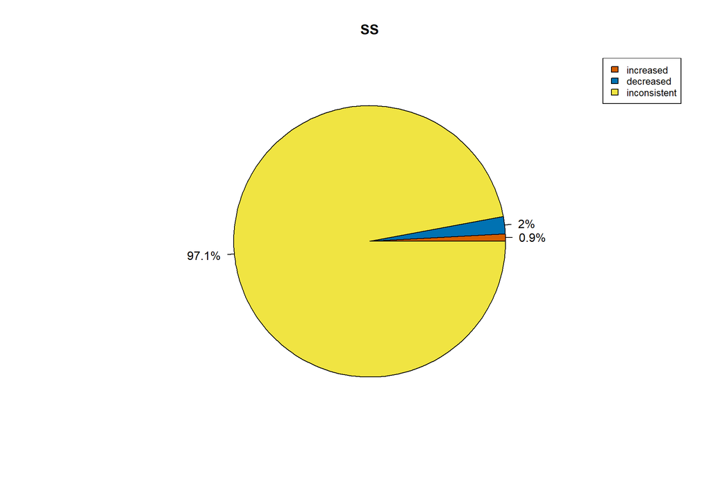

```r
pop <- "SS"

freqs_win <- read.table(paste("C:/Users/jmcgirr/Documents/Whitehead_Lab/ph/freqs/window/",pop,"_shifts_",win,"_win_",step,"_step.txt", sep = ""))
freqs_win$chr_num <- factor(freqs_win$chr, levels = c(1:26))
colnames(freqs_win)[c(1:3)] <- c("seqnames","start","end")


# identify windows where allele frequencies increased between each sampling period
increased_freq <- freqs_win[freqs_win$zt12_mean > 0 &
                            freqs_win$zt23_mean > 0,]
#nrow(increased_freq)
#nrow(increased_freq) / nrow(freqs_win)
# identify windows where allele frequencies increased between each sampling period
decreased_freq <- freqs_win[freqs_win$zt12_mean < 0 &
                            freqs_win$zt23_mean < 0,]
#nrow(decreased_freq)
#nrow(decreased_freq) / nrow(freqs_win)

inc <- nrow(increased_freq)
dec <- nrow(decreased_freq)
remain <- nrow(freqs_win)-(inc+dec)
pie(c(inc,dec,remain), col = c(red, blu, yel), main = "SS",
    labels = c(paste(round(inc/nrow(freqs_win),3)*100, "%", sep = ""),
               paste(round(dec/nrow(freqs_win),3)*100, "%", sep = ""),
               paste(round(remain/nrow(freqs_win),3)*100, "%", sep = "")))
legend("topright", c("increased", "decreased", "inconsistent"), cex = 0.8,
   fill = c(red, blu, yel))
```

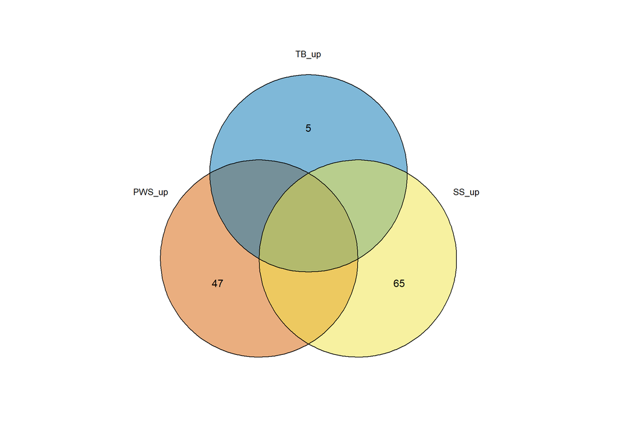

```r
pws_increased_freq$windex <- paste(pws_increased_freq$seqnames, pws_increased_freq$win_mid, sep = ":")
pws_decreased_freq$windex <- paste(pws_decreased_freq$seqnames, pws_decreased_freq$win_mid, sep = ":")
tb_increased_freq$windex <- paste(tb_increased_freq$seqnames, tb_increased_freq$win_mid, sep = ":")
tb_decreased_freq$windex <- paste(tb_decreased_freq$seqnames, tb_decreased_freq$win_mid, sep = ":")
increased_freq$windex <- paste(increased_freq$seqnames, increased_freq$win_mid, sep = ":")
decreased_freq$windex <- paste(decreased_freq$seqnames, decreased_freq$win_mid, sep = ":")


venn(list(PWS_up=pws_increased_freq$windex,
          TB_up=tb_increased_freq$windex,
          SS_up=increased_freq$windex),
     ilabels = TRUE,opacity = 0.5,box = FALSE,
     zcolor = c(red,blu,yel), ilcs = 1)
```

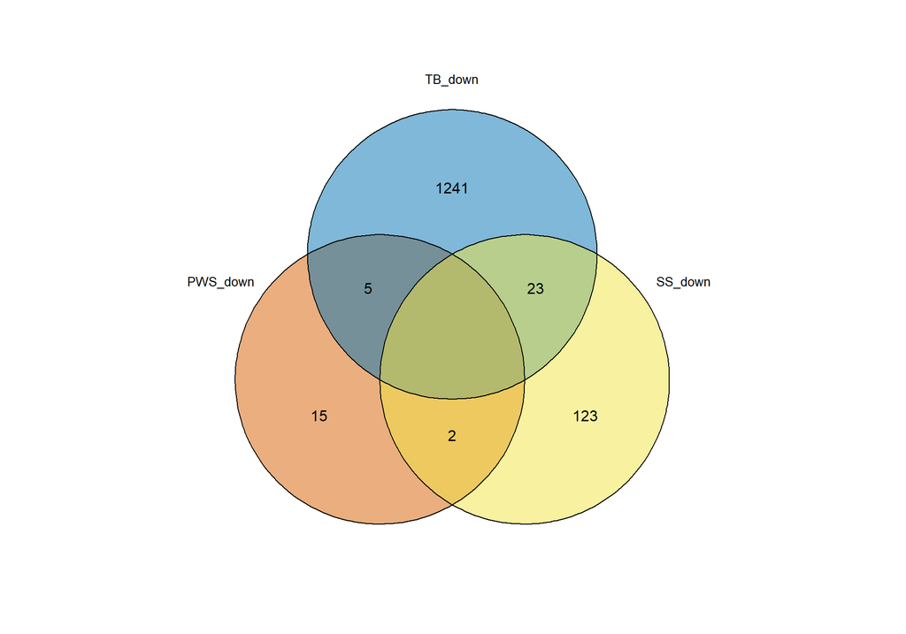

```r
venn(list(PWS_down=pws_decreased_freq$windex,
          TB_down=tb_decreased_freq$windex,
          SS_down=decreased_freq$windex),
     ilabels = TRUE,opacity = 0.5,box = FALSE,
     zcolor = c(red,blu,yel), ilcs = 1)
```

# Identify windows where allele frequencies showed LARGE shifts in the same direction:

Are there any windows that show:

- ∆z > 90th percentile across all sampling periods
- ∆z < 10th percentile across all sampling periods

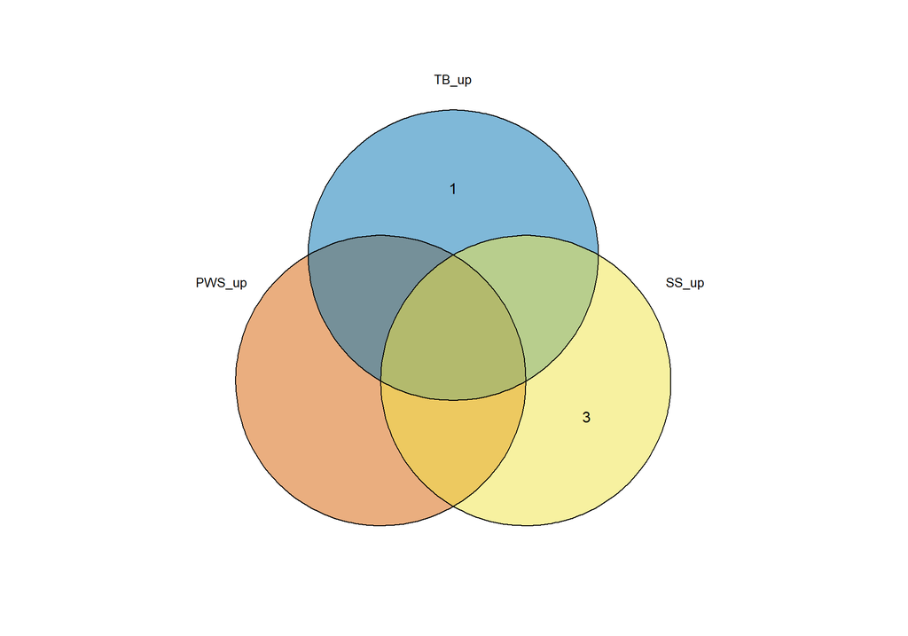

```r
pop <- "PWS"

freqs_win <- read.table(paste("C:/Users/jmcgirr/Documents/Whitehead_Lab/ph/freqs/window/",pop,"_shifts_",win,"_win_",step,"_step.txt", sep = ""))
freqs_win$chr_num <- factor(freqs_win$chr, levels = c(1:26))
colnames(freqs_win)[c(1:3)] <- c("seqnames","start","end")
# identify windows where allele frequencies increased between each sampling period
pws_increased_freq <- freqs_win[freqs_win$zt01_mean >= quantile(freqs_win$zt01_mean, .9)[[1]] &
                           freqs_win$zt12_mean >= quantile(freqs_win$zt12_mean, .9)[[1]] &
                           freqs_win$zt23_mean >= quantile(freqs_win$zt23_mean, .9)[[1]],]

# identify windows where allele frequencies decreased between each sampling period
pws_decreased_freq <- freqs_win[freqs_win$zt01_mean <= quantile(freqs_win$zt01_mean, .1)[[1]] &
                           freqs_win$zt12_mean <= quantile(freqs_win$zt12_mean, .1)[[1]] &
                           freqs_win$zt23_mean <= quantile(freqs_win$zt23_mean, .1)[[1]],]

#print(paste(pop,"increased"))
#print(nrow(top_increased))# / nrow(freqs_win))
#print(paste(pop,"decreased"))
#print(nrow(top_decreased))# / nrow(freqs_win))

#hist(c(top_increased$zt01_mean,
#       top_increased$zt12_mean,
#       top_increased$zt23_mean,
#       top_decreased$zt01_mean,
#       top_decreased$zt12_mean,
#       top_decreased$zt23_mean), xlab = expression(paste(Delta, "z")),
#       main = pop, xlim = c(-0.25, 0.3))


pop <- "TB"

freqs_win <- read.table(paste("C:/Users/jmcgirr/Documents/Whitehead_Lab/ph/freqs/window/",pop,"_shifts_",win,"_win_",step,"_step.txt", sep = ""))
freqs_win$chr_num <- factor(freqs_win$chr, levels = c(1:26))
colnames(freqs_win)[c(1:3)] <- c("seqnames","start","end")
# identify windows where allele frequencies increased between each sampling period
tb_increased_freq <- freqs_win[freqs_win$zt01_mean >= quantile(freqs_win$zt01_mean, .9)[[1]] &
                           freqs_win$zt12_mean >= quantile(freqs_win$zt12_mean, .9)[[1]] &
                           freqs_win$zt23_mean >= quantile(freqs_win$zt23_mean, .9)[[1]],]

# identify windows where allele frequencies decreased between each sampling period
tb_decreased_freq <- freqs_win[freqs_win$zt01_mean <= quantile(freqs_win$zt01_mean, .1)[[1]] &
                           freqs_win$zt12_mean <= quantile(freqs_win$zt12_mean, .1)[[1]] &
                           freqs_win$zt23_mean <= quantile(freqs_win$zt23_mean, .1)[[1]],]

#print(paste(pop,"increased"))
#print(nrow(top_increased))# / nrow(freqs_win))
#print(paste(pop,"decreased"))
#print(nrow(top_decreased))# / nrow(freqs_win))

#hist(c(top_increased$zt01_mean,
#       top_increased$zt12_mean,
#       top_increased$zt23_mean,
#       top_decreased$zt01_mean,
#       top_decreased$zt12_mean,
#       top_decreased$zt23_mean), xlab = expression(paste(Delta, "z")),
#       main = pop, xlim = c(-0.25, 0.3))


pop <- "SS"

freqs_win <- read.table(paste("C:/Users/jmcgirr/Documents/Whitehead_Lab/ph/freqs/window/",pop,"_shifts_",win,"_win_",step,"_step.txt", sep = ""))
freqs_win$chr_num <- factor(freqs_win$chr, levels = c(1:26))
colnames(freqs_win)[c(1:3)] <- c("seqnames","start","end")
# identify windows where allele frequencies increased between each sampling period
ss_increased_freq <- freqs_win[freqs_win$zt12_mean >= quantile(freqs_win$zt12_mean, .9)[[1]] &
                               freqs_win$zt23_mean >= quantile(freqs_win$zt23_mean, .9)[[1]],]

# identify windows where allele frequencies decreased between each sampling period
ss_decreased_freq <- freqs_win[freqs_win$zt12_mean <= quantile(freqs_win$zt12_mean, .1)[[1]] &
                               freqs_win$zt23_mean <= quantile(freqs_win$zt23_mean, .1)[[1]],]



pws_increased_freq$windex <- paste(pws_increased_freq$seqnames, pws_increased_freq$win_mid, sep = ":")
pws_decreased_freq$windex <- paste(pws_decreased_freq$seqnames, pws_decreased_freq$win_mid, sep = ":")

tb_increased_freq$windex <- paste(tb_increased_freq$seqnames, tb_increased_freq$win_mid, sep = ":")
tb_decreased_freq$windex <- paste(tb_decreased_freq$seqnames, tb_decreased_freq$win_mid, sep = ":")

ss_increased_freq$windex <- paste(ss_increased_freq$seqnames, ss_increased_freq$win_mid, sep = ":")
ss_decreased_freq$windex <- paste(ss_decreased_freq$seqnames, ss_decreased_freq$win_mid, sep = ":")


venn(list(PWS_up=pws_increased_freq$windex,
          TB_up=tb_increased_freq$windex,
          SS_up=ss_increased_freq$windex),
     ilabels = TRUE,opacity = 0.5,box = FALSE,
     zcolor = c(red,blu,yel), ilcs = 1)
```

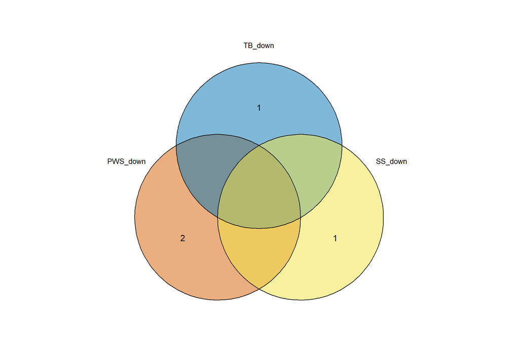

```r
venn(list(PWS_down=pws_decreased_freq$windex,
          TB_down=tb_decreased_freq$windex,
          SS_down=ss_decreased_freq$windex),
     ilabels = TRUE,opacity = 0.5,box = FALSE,
     zcolor = c(red,blu,yel), ilcs = 1)
```

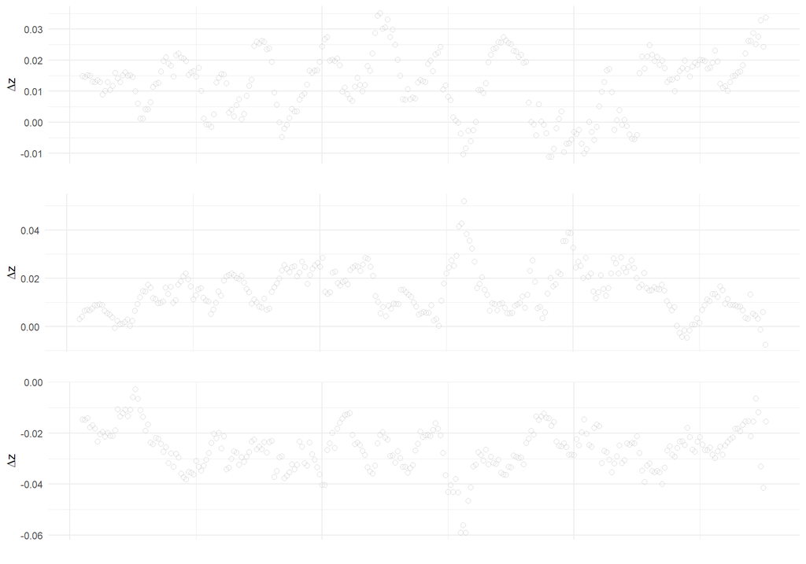

```r
pop <- "PWS"

freqs_win <- read.table(paste("C:/Users/jmcgirr/Documents/Whitehead_Lab/ph/freqs/window/",pop,"_shifts_",win,"_win_",step,"_step.txt", sep = ""))
freqs_win$chr_num <- factor(freqs_win$chr, levels = c(1:26))

# identify windows where allele frequencies increased between each sampling period
top_increased <- freqs_win[freqs_win$zt01_mean >= quantile(freqs_win$zt01_mean, .9)[[1]] &
                           freqs_win$zt12_mean >= quantile(freqs_win$zt12_mean, .9)[[1]] &
                           freqs_win$zt23_mean >= quantile(freqs_win$zt23_mean, .9)[[1]],]

# identify windows where allele frequencies decreased between each sampling period
top_decreased <- freqs_win[freqs_win$zt01_mean <= quantile(freqs_win$zt01_mean, .1)[[1]] &
                           freqs_win$zt12_mean <= quantile(freqs_win$zt12_mean, .1)[[1]] &
                           freqs_win$zt23_mean <= quantile(freqs_win$zt23_mean, .1)[[1]],]

# PWS chr with strongest positive shift (18)

freqs_win1 <- freqs_win[freqs_win$chr == "18",]
top_increased1 <- top_increased[top_increased$chr == "18",]

p01 <- ggplot(freqs_win1, aes(x = win_mid, y = zt01_mean)) +
     geom_point(size = 2, color = gry,alpha = 0.6, shape = 1)+
     theme_minimal()+
     theme(axis.text.x=element_blank())+
     ylab(expression(paste(Delta, "z")))+ xlab("")+
     geom_vline(aes(xintercept = win_mid), top_increased1)
p12 <- ggplot(freqs_win1, aes(x = win_mid, y = zt12_mean)) +
     geom_point(size = 2, color = gry,alpha = 0.6, shape = 1)+
     theme_minimal()+
     theme(axis.text.x=element_blank())+
     ylab(expression(paste(Delta, "z")))+ xlab("")+
     geom_vline(aes(xintercept = win_mid), top_increased1)
p23 <- ggplot(freqs_win1, aes(x = win_mid, y = zt23_mean)) +
     geom_point(size = 2, color = gry,alpha = 0.6, shape = 1)+
     theme_minimal()+
     theme(axis.text.x=element_blank())+
     ylab(expression(paste(Delta, "z")))+ xlab("")+
     geom_vline(aes(xintercept = win_mid), top_increased1)

#p + geom_vline(aes(xintercept = win_mid), tops)

ggarrange(p01,p12,p23, ncol = 1, nrow = 3)#,
```

```r
          #labels = c("A", "B", "C"))

# Find genes in regions

gff <- read.delim("C:/Users/jmcgirr/Documents/Whitehead_Lab/ph/annotations/Clupea_harengus.Ch_v2.0.2.100.gff3",header = FALSE, sep = "\t",comment.char = '#')
#head(gff)
colnames(gff) <- c("seqnames","source","type","start","end","score","strand","phase","attributes")
genes <- gff[gff$type=="gene",]
genes <- genes %>% separate(attributes, c("at1","at2"), remove = FALSE,sep = "Name=") %>% separate(at2, c("gene_name","at3"), extra = "drop",sep = ";")
genes <- select(genes, -at1,-at3)
g <- genes[genes$strand == "\\.",]
#head(genes)
genes <- droplevels(genes)

genes <- genes %>% as_granges()

names(top_increased)[names(top_increased) == "chr"] <- "seqnames"
names(top_increased)[names(top_increased) == "win_start"] <- "start"
names(top_increased)[names(top_increased) == "win_end"] <- "end"

names(top_decreased)[names(top_decreased) == "chr"] <- "seqnames"
names(top_decreased)[names(top_decreased) == "win_start"] <- "start"
names(top_decreased)[names(top_decreased) == "win_end"] <- "end"


tops <- rbind(top_increased,top_decreased)

tops<- tops %>% as_granges()

genes_overlap <- join_overlap_intersect(tops, genes) %>% as.data.frame()

#write.table(as.data.frame(unique(na.omit(focal_chr_genes$gene_name))), "C:/Users/jmcgirr/Documents/Whitehead_Lab/ph/GO/fst_outliers/PWS17_v_TB17_Fst_99percentile_genes.txt", quote= FALSE, row.names = FALSE, col.names = FALSE)
```

# Identify windows where allele frequencies showed shifts after collapse and reversed over time:

- increased between 91 and 96, decreased between 96 and 07, and continued to decrease between 07 and 17
- decreased between 91 and 96, increased between 96 and 07, and continued to increase between 07 and 17

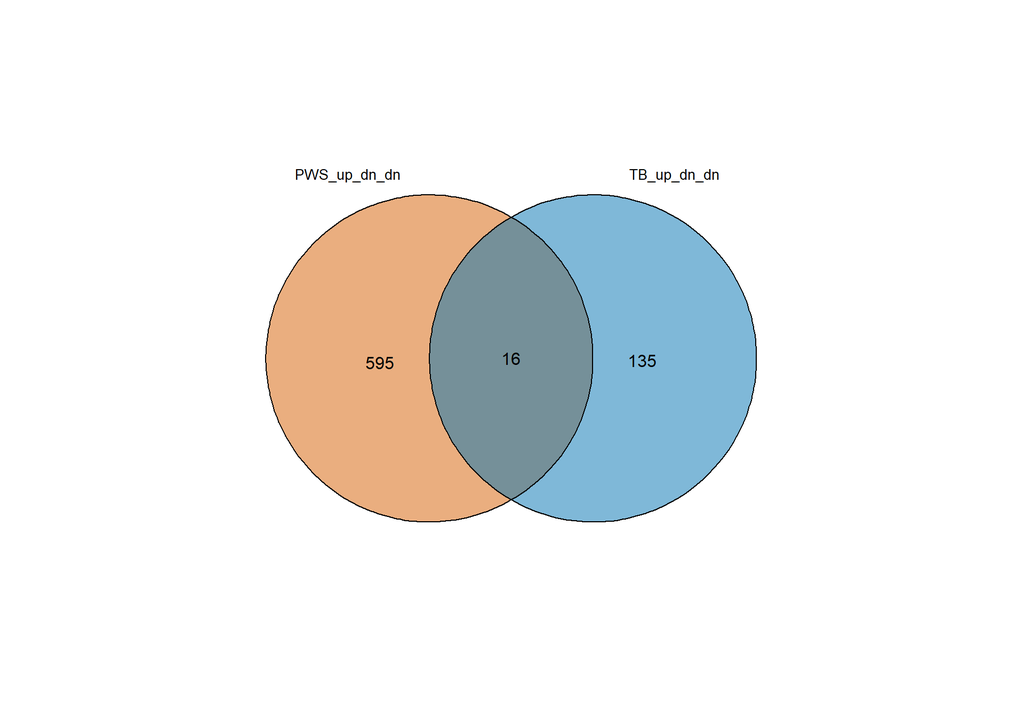

```r
pop <- "PWS"

freqs_win <- read.table(paste("C:/Users/jmcgirr/Documents/Whitehead_Lab/ph/freqs/window/",pop,"_shifts_",win,"_win_",step,"_step.txt", sep = ""))
freqs_win$chr_num <- factor(freqs_win$chr, levels = c(1:26))
colnames(freqs_win)[c(1:3)] <- c("seqnames","start","end")

# identify windows where allele frequencies increased between 91 and 96
# and decreased between 96 and 07
# and continued to decrease between 07 and 17
pws_up_dn_dn <- freqs_win[freqs_win$zt01_mean >= 0 &
                               freqs_win$zt12_mean <= 0 &
                               freqs_win$zt23_mean <= 0,]

# identify windows where allele frequencies decreased between 91 and 96
# and increased between 96 and 07
# and continued to increase between 07 and 17
pws_dn_up_up <- freqs_win[freqs_win$zt01_mean <= 0 &
                               freqs_win$zt12_mean >= 0 &
                               freqs_win$zt23_mean >= 0,]

#print(paste(pop,"up_dn_dn"))
#up_dn_dn# / nrow(freqs_win)
#print(paste(pop,"dn_up_up"))
#dn_up_up# / nrow(freqs_win)
#
#print(hist(c(up_dn_dn$zt01_mean,
#             up_dn_dn$zt12_mean,
#             up_dn_dn$zt23_mean,
#             dn_up_up$zt01_mean,
#             dn_up_up$zt12_mean,
#             dn_up_up$zt23_mean), xlab = expression(paste(Delta, "z")),
#             main = pop))#, xlim = c(-0.25, 0.3)))

pop <- "TB"

freqs_win <- read.table(paste("C:/Users/jmcgirr/Documents/Whitehead_Lab/ph/freqs/window/",pop,"_shifts_",win,"_win_",step,"_step.txt", sep = ""))
freqs_win$chr_num <- factor(freqs_win$chr, levels = c(1:26))
colnames(freqs_win)[c(1:3)] <- c("seqnames","start","end")

# identify windows where allele frequencies increased between 91 and 96
# and decreased between 96 and 07
# and continued to decrease between 07 and 17
tb_up_dn_dn <- freqs_win[freqs_win$zt01_mean >= 0 &
                               freqs_win$zt12_mean <= 0 &
                               freqs_win$zt23_mean <= 0,]

# identify windows where allele frequencies decreased between 91 and 96
# and increased between 96 and 07
# and continued to increase between 07 and 17
tb_dn_up_up <- freqs_win[freqs_win$zt01_mean <= 0 &
                               freqs_win$zt12_mean >= 0 &
                               freqs_win$zt23_mean >= 0,]


pws_up_dn_dn$windex <- paste(pws_up_dn_dn$seqnames, pws_up_dn_dn$win_mid, sep = ":")
pws_dn_up_up$windex <- paste(pws_dn_up_up$seqnames, pws_dn_up_up$win_mid, sep = ":")

tb_up_dn_dn$windex <- paste(tb_up_dn_dn$seqnames, tb_up_dn_dn$win_mid, sep = ":")
tb_dn_up_up$windex <- paste(tb_dn_up_up$seqnames, tb_dn_up_up$win_mid, sep = ":")


venn(list(PWS_up_dn_dn=pws_up_dn_dn$windex,
          TB_up_dn_dn=tb_up_dn_dn$windex),
     ilabels = TRUE,opacity = 0.5,box = FALSE,
     zcolor = c(red,blu,yel), ilcs = 1)
```

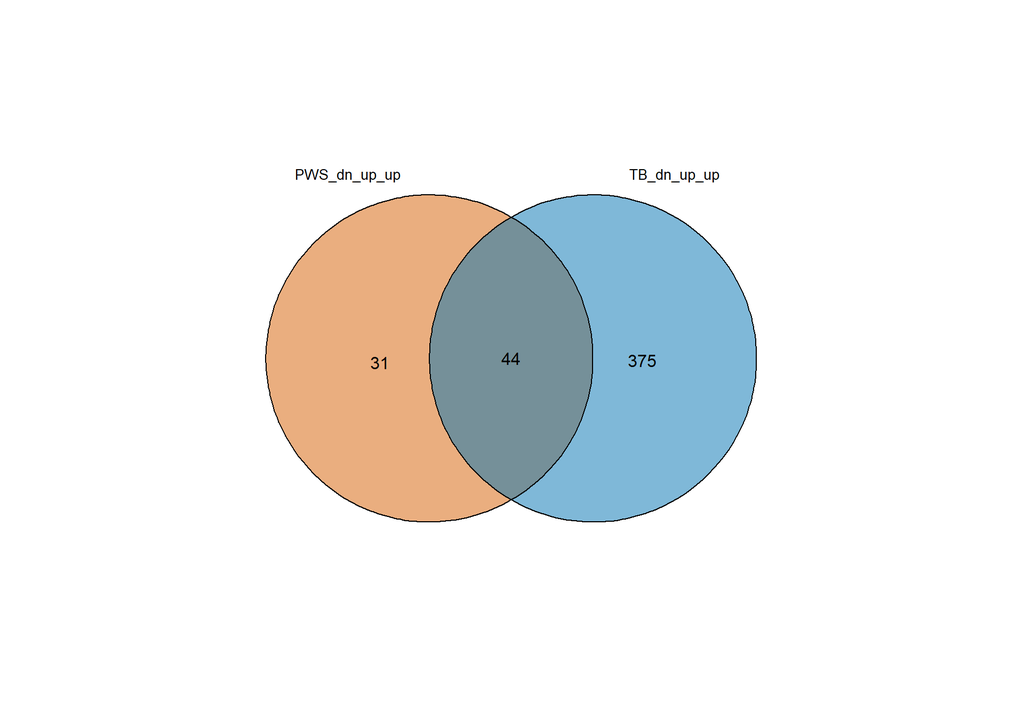

```r
venn(list(PWS_dn_up_up=pws_dn_up_up$windex,
          TB_dn_up_up=tb_dn_up_up$windex),
     ilabels = TRUE,opacity = 0.5,box = FALSE,
     zcolor = c(red,blu,yel), ilcs = 1)
```